# BAA1030 Individual Assignment 2

Youth Refugee Asylum Trends Across Nations

Author

Dominic George Augustine

Published

April 1, 2025

Imagine a world where millions of children are forced to flee their homes, seeking safety in unfamiliar lands. **Iran** emerges as the largest host of refugee children under 18, followed closely by **Turkey, Pakistan, Uganda, and Germany** placing a heavy burden on these nations.

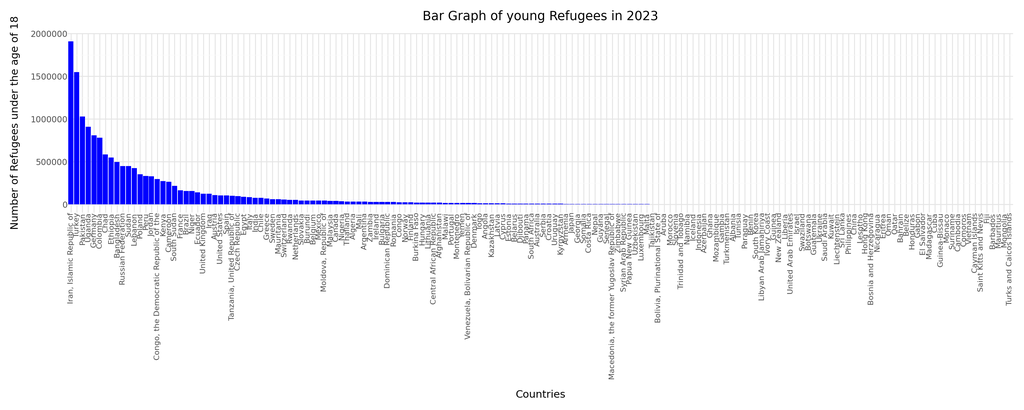

```python
import polars as pl
from plotnine import *
import geopandas as gpd

df=pl.read_csv("/content/unicef_indicator_1.csv")                               # to Read file

df_2023 = (df.filter(pl.col("year") == 2023))                                   # Filter data for the year 2023

# ---- BAR GRAPH

df_pd = df_2023.to_pandas()                                                     # to convert to pandas

df_pd = df_pd.sort_values(by="obs_value", ascending=False)                      # sorting, makes the graph looks better

bar_chart = (ggplot(df_pd, aes(x="country", y="obs_value"))                     # define x and y axis
    + geom_bar(stat="identity", fill="blue")                                    # assigning blue color
    + scale_x_discrete(limits=df_pd["country"].tolist())                        # Sort x-axis
    + theme_minimal()                                                           # theme select
    + theme(
        axis_text_x=element_text(rotation=90, size=8),                          # Rotate & adjust text size
        figure_size=(15, 6))
    + labs(                                                                     # to add labels
      x="Countries",
      y="Number of Refugees under the age of 18",
      title="Bar Graph of young Refugees in 2023")
)

bar_chart.show()                                                                # display the bar chart
```

The bar graph starkly illustrates this uneven burden—while a few nations provide refuge to countless displaced children, many others play only a minimal role. As the bars shrink, they serve as a reminder that the responsibility of protecting the world’s most vulnerable should not rest on the shoulders of a few but be shared by all.

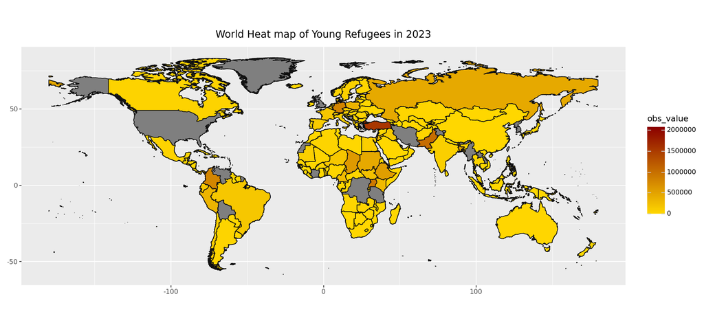

```python
# ---- WORLD MAP
world = gpd.read_file("https://public.opendatasoft.com/api/explore/v2.1/catalog/datasets/world-administrative-boundaries/exports/shp")
(ggplot()
  + geom_map(world)                                                             # to obtain the world map outline/shape
)
map_df_2023 = (world
  .merge(df.to_pandas(), left_on="name", right_on="country", how="outer")       # to assign the values
)
map_2023 = (ggplot(data=map_df_2023)                                            # to plot the graph
  + aes(fill="obs_value")
  + geom_map()
  + labs(title="World Heat map of Young Refugees in 2023")
  + scale_fill_gradient(low="#FFD700", high="#8B0000")                          # Applied hex values for gold and dark red
  + coord_fixed()
  + theme(
        figure_size=(13, 6))                                                    # resize the map
)
map_2023.show()                                                                 # display the World map
```

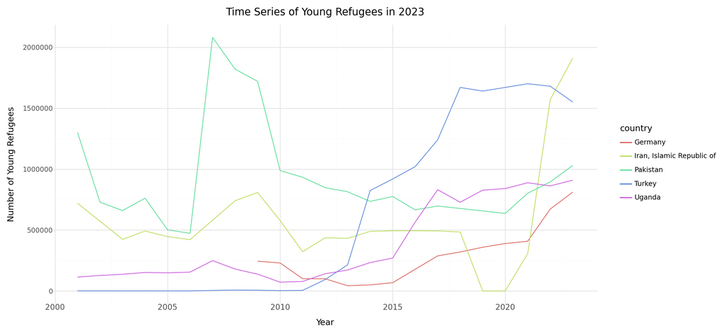

```python
# ---- TIME SERIES MAP
df_iran = (df
  .filter(pl.col("country").
          is_in(["Iran, Islamic Republic of", "Turkey", "Pakistan", "Uganda", "Germany"]))
)
time_series_plot = (ggplot(df_iran, aes(x="year", y="obs_value", color="country"))  # Create a time series chart
    + geom_line()                                                               # Line plot
    + labs(
        title="Time Series of Young Refugees in 2023",
        x="Year",
        y="Number of Young Refugees"
    )
    + theme_minimal()
    + theme(
        axis_text_x=element_text(rotation=0, size=10),                          # Rotate x-axis labels
        figure_size=(13, 6)                                                     # Increase figure size
    )
)
time_series_plot.show()                                                         # to dispay the graph
```

The time-series chart tells a more dynamic story, tracking how child welfare indicators shift over time. Policy changes, global crises, and economic growth leave their imprints, shaping the futures of millions.

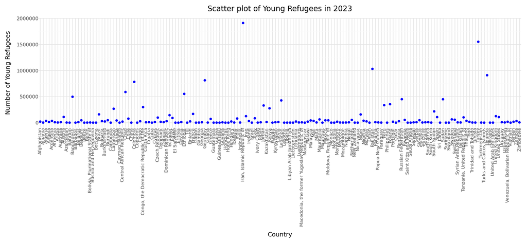

```python
# ---- scatter plot with a regression line
scatter_plot = (ggplot(df_2023, aes(x=df_2023.columns[0], y=df_2023.columns[2]))  # Adjust column names
    + geom_point(color="blue")                                                  # Scatter plot points
    + labs(
        title="Scatter plot of Young Refugees in 2023",
        x="Country",
        y="Number of Young Refugees"
    )
    + theme_minimal()
    + theme(
        axis_text_x=element_text(rotation=90, size=8),                          # Rotate x-axis labels for readability
        figure_size=(13, 6)                                                     # Increase figure size
    )
)
scatter_plot.show()                                                             # Display the scatter plot
```

**These insights remind us that beyond the numbers are real lives in need of support, urging the global community to step up and share the responsibility.**